# group7

### **Objective:**

To understand and gain insights from a retail dataset by performing various exploratory data analyses, data visualization, and data modelling.

### **Dataset Columns:**

- **InvoiceNo:** Invoice number. A unique number per invoice.
- **StockCode:** Product code. A unique number per product.
- **Description:** Product description.
- **Quantity:** The number of products sold per invoice.
- **InvoiceDate:** The date and time of the invoice.
- **UnitPrice:** The price of one unit of the product.
- **CustomerID:** Customer identification number.
- **Country:** The country where the customer resides.

## 1. Data Preprocessing and Cleaning:

1.1. Import necessary libraries and read the dataset:

```python
import pandas as pd
import matplotlib.pyplot as plt
import seaborn as sns
import numpy as np
from sklearn.preprocessing import StandardScaler
from sklearn.cluster import KMeans
from sklearn.model_selection import train_test_split
from sklearn.ensemble import RandomForestRegressor
from sklearn.metrics import mean_absolute_error,r2_score
from sklearn.metrics import classification_report
from sklearn.metrics.pairwise import cosine_similarity
from sklearn.linear_model import LogisticRegression
from sklearn.model_selection import train_test_split
from sklearn.metrics import classification_report
```

```python
data = pd.read_csv('Sales_data.csv', encoding_errors ='ignore' )
```

```python
data.shape
```

```
(541909, 8)
```

```python
data.describe().T  #include ="all"
```

|  | count | mean | std | min | 25% | 50% | 75% | max |
| --- | --- | --- | --- | --- | --- | --- | --- | --- |
| Quantity | 541909.0 | 9.552250 | 218.081158 | -80995.00 | 1.00 | 3.00 | 10.00 | 80995.0 |
| UnitPrice | 541909.0 | 4.611114 | 96.759853 | -11062.06 | 1.25 | 2.08 | 4.13 | 38970.0 |
| CustomerID | 406829.0 | 15287.690570 | 1713.600303 | 12346.00 | 13953.00 | 15152.00 | 16791.00 | 18287.0 |

1.2. Display the top 10 rows of the dataframe:

```python
data.head(10)
```

|  | InvoiceNo | StockCode | Description | Quantity | InvoiceDate | UnitPrice | CustomerID | Country |
| --- | --- | --- | --- | --- | --- | --- | --- | --- |
| 0 | 536365 | 85123A | WHITE HANGING HEART T-LIGHT HOLDER | 6 | 12/1/2010 8:26 | 2.55 | 17850.0 | United Kingdom |
| 1 | 536365 | 71053 | WHITE METAL LANTERN | 6 | 12/1/2010 8:26 | 3.39 | 17850.0 | United Kingdom |
| 2 | 536365 | 84406B | CREAM CUPID HEARTS COAT HANGER | 8 | 12/1/2010 8:26 | 2.75 | 17850.0 | United Kingdom |
| 3 | 536365 | 84029G | KNITTED UNION FLAG HOT WATER BOTTLE | 6 | 12/1/2010 8:26 | 3.39 | 17850.0 | United Kingdom |
| 4 | 536365 | 84029E | RED WOOLLY HOTTIE WHITE HEART. | 6 | 12/1/2010 8:26 | 3.39 | 17850.0 | United Kingdom |
| 5 | 536365 | 22752 | SET 7 BABUSHKA NESTING BOXES | 2 | 12/1/2010 8:26 | 7.65 | 17850.0 | United Kingdom |
| 6 | 536365 | 21730 | GLASS STAR FROSTED T-LIGHT HOLDER | 6 | 12/1/2010 8:26 | 4.25 | 17850.0 | United Kingdom |
| 7 | 536366 | 22633 | HAND WARMER UNION JACK | 6 | 12/1/2010 8:28 | 1.85 | 17850.0 | United Kingdom |
| 8 | 536366 | 22632 | HAND WARMER RED POLKA DOT | 6 | 12/1/2010 8:28 | 1.85 | 17850.0 | United Kingdom |
| 9 | 536367 | 84879 | ASSORTED COLOUR BIRD ORNAMENT | 32 | 12/1/2010 8:34 | 1.69 | 13047.0 | United Kingdom |

1.3. Check for missing values:

```python
data.isnull().sum()
```

```
InvoiceNo           0
StockCode           0
Description      1454
Quantity            0
InvoiceDate         0
UnitPrice           0
CustomerID     135080
Country             0
dtype: int64
```

##### Handling Missing Values

```python
data['Description'].fillna('Unknown', inplace=True)
data['CustomerID'].fillna('Guest', inplace=True)
```

```python
data.isnull().sum()
```

```
InvoiceNo      0
StockCode      0
Description    0
Quantity       0
InvoiceDate    0
UnitPrice      0
CustomerID     0
Country        0
dtype: int64
```

1.4. Convert the InvoiceDate column to datetime format:

```python
data.dtypes
```

```
InvoiceNo       object
StockCode       object
Description     object
Quantity         int64
InvoiceDate     object
UnitPrice      float64
CustomerID      object
Country         object
dtype: object
```

```python
data['InvoiceDate'] = pd.to_datetime(data['InvoiceDate'])
```

```python
data.dtypes
```

```
InvoiceNo              object
StockCode              object
Description            object
Quantity                int64
InvoiceDate    datetime64[ns]
UnitPrice             float64
CustomerID             object
Country                object
dtype: object
```

1.5. Add a new column 'TotalPrice' to the dataframe which is the product of 'UnitPrice' and 'Quantity':

```python
data['TotalPrice']=data['UnitPrice']*data['Quantity']
```

```python
data.columns
```

```
Index(['InvoiceNo', 'StockCode', 'Description', 'Quantity', 'InvoiceDate',
       'UnitPrice', 'CustomerID', 'Country', 'TotalPrice'],
      dtype='object')
```

## 2. Exploratory Data Analysis:

2.1. How many unique products are there in the dataset?

```python
data.StockCode.nunique()
```

```
4070
```

2.2. Which are the top 10 products (using StockCode) sold by quantity?

```python
#Exploring all Unique values for Quantity and arranging them in ascending order
sorted(data.Quantity.unique())
```

[output not shown]

[output cut: 667 more lines]

```
 2592,
 2700,
 2880,
 3000,
 3100,
 3114,
 3186,
 3906,
 4000,
 4300,
 4800,
 5568,
 12540,
 74215,
 80995]
```

```python
# viewing rows containing negative quantity values
negative_quantities = data[data['Quantity'] < 0]
negative_quantities.sample(5)
```

|  | InvoiceNo | StockCode | Description | Quantity | InvoiceDate | UnitPrice | CustomerID | Country | TotalPrice |
| --- | --- | --- | --- | --- | --- | --- | --- | --- | --- |
| 454399 | C575572 | 21754 | HOME BUILDING BLOCK WORD | -1 | 2011-11-10 11:33:00 | 6.25 | 17528.0 | United Kingdom | -6.25 |
| 88060 | C543755 | 85045 | GREEN CHRISTMAS TREE STRING 20LIGHT | -4 | 2011-02-11 14:48:00 | 4.95 | 14304.0 | United Kingdom | -19.80 |
| 304699 | C563611 | 84755 | COLOUR GLASS T-LIGHT HOLDER HANGING | -1 | 2011-08-18 06:38:00 | 0.65 | 17340.0 | United Kingdom | -0.65 |
| 138909 | 548227 | 90099 | Unknown | -19 | 2011-03-30 10:24:00 | 0.00 | Guest | United Kingdom | -0.00 |
| 218103 | 556014 | 37476 | Unknown | -3 | 2011-06-08 11:46:00 | 0.00 | Guest | United Kingdom | -0.00 |

```python
negative_unit_price = data[data['UnitPrice'] < 0]
negative_unit_price.sample(2)
```

|  | InvoiceNo | StockCode | Description | Quantity | InvoiceDate | UnitPrice | CustomerID | Country | TotalPrice |
| --- | --- | --- | --- | --- | --- | --- | --- | --- | --- |
| 299984 | A563187 | B | Adjust bad debt | 1 | 2011-08-12 14:52:00 | -11062.06 | Guest | United Kingdom | -11062.06 |
| 299983 | A563186 | B | Adjust bad debt | 1 | 2011-08-12 14:51:00 | -11062.06 | Guest | United Kingdom | -11062.06 |

```python
# Removing all rows containign Negative quqntity values
# Dataset without negative quantity values is called new_data
new_data = data[data['Quantity'] >= 0]
new_data = new_data[new_data['UnitPrice'] >= 0]
print (new_data.shape)
new_data.head(3)
```

```
(531283, 9)
```

|  | InvoiceNo | StockCode | Description | Quantity | InvoiceDate | UnitPrice | CustomerID | Country | TotalPrice |
| --- | --- | --- | --- | --- | --- | --- | --- | --- | --- |
| 0 | 536365 | 85123A | WHITE HANGING HEART T-LIGHT HOLDER | 6 | 2010-12-01 08:26:00 | 2.55 | 17850.0 | United Kingdom | 15.30 |
| 1 | 536365 | 71053 | WHITE METAL LANTERN | 6 | 2010-12-01 08:26:00 | 3.39 | 17850.0 | United Kingdom | 20.34 |
| 2 | 536365 | 84406B | CREAM CUPID HEARTS COAT HANGER | 8 | 2010-12-01 08:26:00 | 2.75 | 17850.0 | United Kingdom | 22.00 |

```python
top_10_products = new_data.groupby('StockCode')['Quantity'].sum().sort_values(ascending=False).head(10)
top_10_products
```

```
StockCode
23843     80995
23166     78033
22197     56921
84077     55047
85099B    48478
85123A    41664
84879     36461
21212     36419
23084     31722
22492     26633
Name: Quantity, dtype: int64
```

2.3. How many unique customers are there in the dataset?

```python
new_data.CustomerID.nunique()
```

```
4340
```

2.4. Which country has the maximum number of unique customers?

```python
new_data.groupby('Country')['CustomerID'].nunique().sort_values(ascending=False).head(1)
```

```
Country
United Kingdom    3922
Name: CustomerID, dtype: int64
```

2.5. Visualize the distribution of 'TotalPrice' using a histogram.

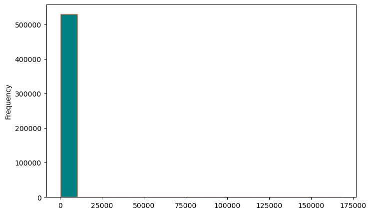

```python
new_data['TotalPrice'].plot.hist(figsize=(8,5), color='teal', edgecolor='coral', bins=16, rwidth=0.98, align='mid')
```

```python
#Trying to Understand why we got the above graph for the total price column
# We Observe that 75% of the data in the totalprice column is less than 17.7 with a median value of 9.90
new_data['TotalPrice'].describe()
```

```
count    531283.000000
mean         20.077218
std         270.058254
min           0.000000
25%           3.750000
50%           9.900000
75%          17.700000
max      168469.600000
Name: TotalPrice, dtype: float64
```

```python
# Splitting the Totalprice column into quantiles, the output is ordered by frequency size
# Here we observe that Total price values between 19.8 and 168,469 have the lowest frequencies
pd.qcut(new_data['TotalPrice'], q=5).value_counts().sort_index()
```

```
TotalPrice
(-0.001, 3.25]      106803
(3.25, 6.6]         105777
(6.6, 13.16]        106877
(13.16, 19.8]       106791
(19.8, 168469.6]    105035
Name: count, dtype: int64
```

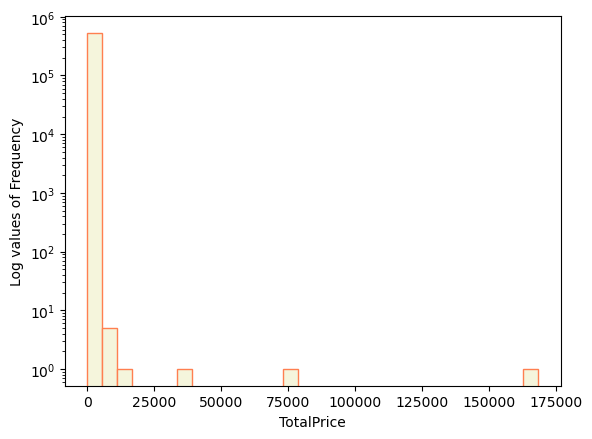

```python
#Using the log to shrink the difference in frequency size
plt.hist(new_data['TotalPrice'], edgecolor='coral', color = 'beige', bins=30, log= True, align='mid')
plt.xlabel('TotalPrice')
plt.ylabel('Log values of Frequency')
plt.show()
```

## 3. Data Aggregation:

3.1. Compute the total sales (TotalPrice) per country.

```python
# Compute the total sales (TotalPrice) per country
sales_per_country = new_data.groupby('Country')['TotalPrice'].sum().sort_values(ascending=False)#.reset_index()
sales_per_country
```

```
Country
United Kingdom          9025222.084
Netherlands              285446.340
EIRE                     283453.960
Germany                  228867.140
France                   209715.110
Australia                138521.310
Spain                     61577.110
Switzerland               57089.900
Belgium                   41196.340
Sweden                    38378.330
Japan                     37416.370
Norway                    36165.440
Portugal                  33747.100
Finland                   22546.080
Singapore                 21279.290
Channel Islands           20450.440
Denmark                   18955.340
Italy                     17483.240
Hong Kong                 15691.800
Cyprus                    13590.380
Austria                   10198.680
Israel                     8135.260
Poland                     7334.650
Greece                     4760.520
Unspecified                4749.790
Iceland                    4310.000
Canada                     3666.380
USA                        3580.390
Malta                      2725.590
United Arab Emirates       1902.280
Lebanon                    1693.880
Lithuania                  1661.060
European Community         1300.250
Brazil                     1143.600
RSA                        1002.310
Czech Republic              826.740
Bahrain                     754.140
Saudi Arabia                145.920
Name: TotalPrice, dtype: float64
```

3.2. Identify the month in which the sales were highest.

```python
monthly_sales = new_data.groupby(new_data['InvoiceDate'].dt.to_period('M'))['TotalPrice'].sum().sort_values(ascending=False)
highest_sales_month = monthly_sales.index[0]
highest_sales_value = monthly_sales.values[0]
print(f'highest_sales_month is:{highest_sales_month} and highest_sales_value is:{highest_sales_value}')
```

```
highest_sales_month is:2011-11 and highest_sales_value is:1509496.33
```

3.3. Compute the average unit price per product.

```python
average_unit_price = new_data.groupby('StockCode')['UnitPrice'].mean().sort_values().reset_index()
average_unit_price
```

|  | StockCode | UnitPrice |
| --- | --- | --- |
| 0 | 84971L | 0.000000 |
| 1 | 72803B | 0.000000 |
| 2 | 20950 | 0.000000 |
| 3 | 35951 | 0.000000 |
| 4 | 72814 | 0.000000 |
| ... | ... | ... |
| 3936 | 22828 | 156.428571 |
| 3937 | M | 226.624557 |
| 3938 | DOT | 290.900945 |
| 3939 | AMAZONFEE | 6880.545000 |
| 3940 | B | 11062.060000 |

3941 rows × 2 columns

3.4. Compute the total quantity sold per customer.

```python
quantity_per_customer = new_data.groupby('CustomerID')['Quantity'].sum().sort_values().reset_index()
quantity_per_customer
```

|  | CustomerID | Quantity |
| --- | --- | --- |
| 0 | 17846.0 | 1 |
| 1 | 16742.0 | 1 |
| 2 | 15802.0 | 1 |
| 3 | 15823.0 | 1 |
| 4 | 17956.0 | 1 |
| ... | ... | ... |
| 4335 | 12415.0 | 77670 |
| 4336 | 14911.0 | 80515 |
| 4337 | 16446.0 | 80997 |
| 4338 | 14646.0 | 197491 |
| 4339 | Guest | 479283 |

4340 rows × 2 columns

## 4. Data Visualization:

4.1. Create a bar chart showcasing the sales (TotalPrice) for each country.

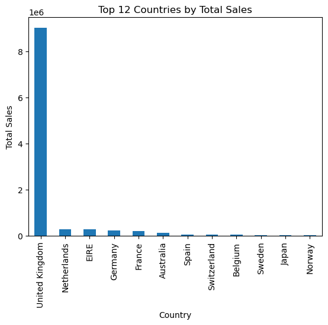

```python
#plt.bar(sales_per_country)
sales_per_country.head(12).plot(kind='bar')
plt.title('Top 12 Countries by Total Sales')
plt.xlabel('Country')
plt.ylabel('Total Sales')
plt.show()
```

4.2. Plot a line graph to showcase the trend of sales over time.

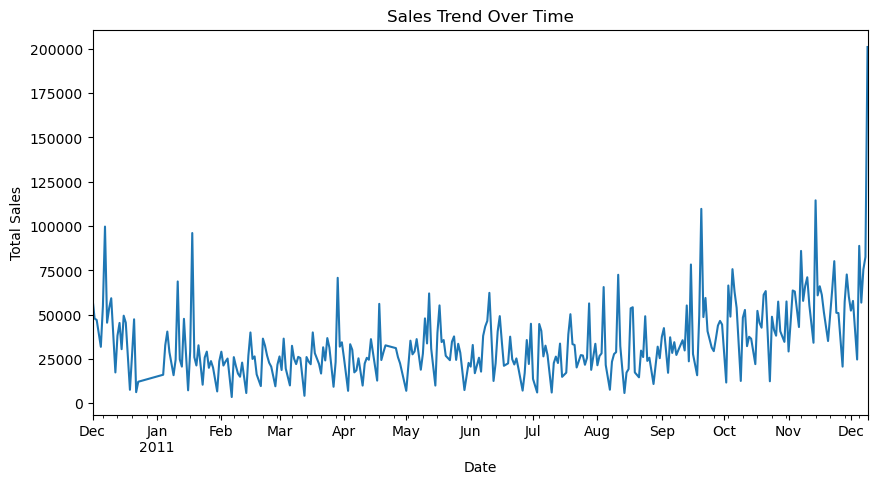

```python
daily_sales = new_data.groupby(new_data['InvoiceDate'].dt.to_period('D'))['TotalPrice'].sum()
daily_sales.plot(kind='line', figsize=(10,5))
plt.title('Sales Trend Over Time')
plt.xlabel('Date')
plt.ylabel('Total Sales')
```

observations: Peaks: There are several peaks in sales, exceeding $80,000. These likely correspond to high-demand periods or special events.

4.3. Use a scatter plot to visualize the relationship between UnitPrice and Quantity.

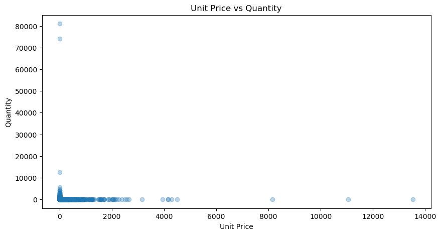

```python
plt.figure(figsize=(10, 5))
plt.scatter(new_data['UnitPrice'], new_data['Quantity'], alpha=0.3)
plt.title('Unit Price vs Quantity')
plt.xlabel('Unit Price')
plt.ylabel('Quantity')
#plt.xscale('log')
#plt.yscale('log')
```

4.4. Plot a heatmap to display the correlation between numeric columns.

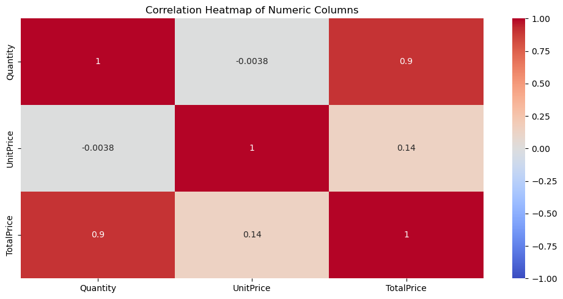

```python
#  Heatmap of correlation between numeric columns
plt.figure(figsize=(10,5))
numeric_columns = new_data.select_dtypes(include=['number']).columns
correlation_matrix = new_data[numeric_columns].corr()
sns.heatmap(correlation_matrix, annot=True, cmap='coolwarm', vmin=-1, vmax=1, center=0)
plt.title('Correlation Heatmap of Numeric Columns')
plt.tight_layout()
plt.show()
```

Quantity vs. TotalPrice:

Here, we see a strong positive correlation (0.9). As the quantity of items sold increases, the total price tends to increase as well in a linear fashion. More sales lead to higher total revenue.

However, Surprisingly the Unit Price of an item doesn't seem to affect the quantity of that item that is purchased.

## 5. Advanced Analysis:

5.1. Identify potential outliers in the dataset for the Quantity and UnitPrice columns using appropriate visualization techniques.

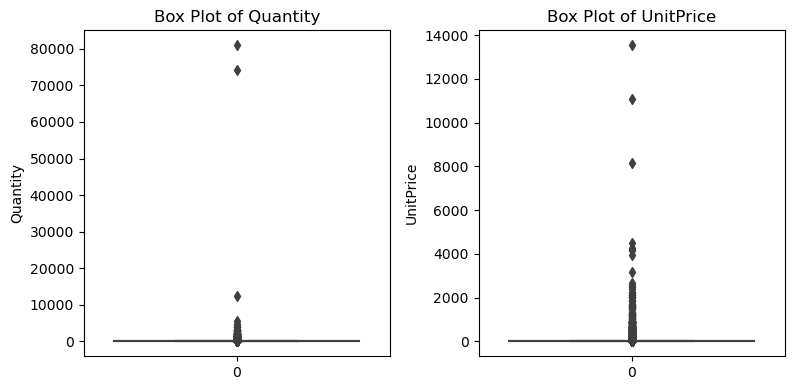

```python
#vis2 =sns.boxplot(data=stat, x="IncomeGroup", y="BirthRate")

plt.figure(figsize=(12, 4))

# Box plot for Quantity
plt.subplot(1, 3, 1)
sns.boxplot(new_data['Quantity'])
plt.title('Box Plot of Quantity')
plt.ylabel('Quantity')

# Box plot for UnitPrice
plt.subplot(1, 3, 2)
sns.boxplot(new_data['UnitPrice'])
plt.title('Box Plot of UnitPrice')
plt.ylabel('UnitPrice')

plt.tight_layout()
plt.show()
```

Based on the above boxplots, quantities above 10,000 can be said to be outliers Unit prices above 8,000 can also besaid to be outliers

- SUBJECT TO SCRUTINY 5.2. Segment customers based on their purchase history (Consider factors like total purchases, frequency of purchases, etc.).*

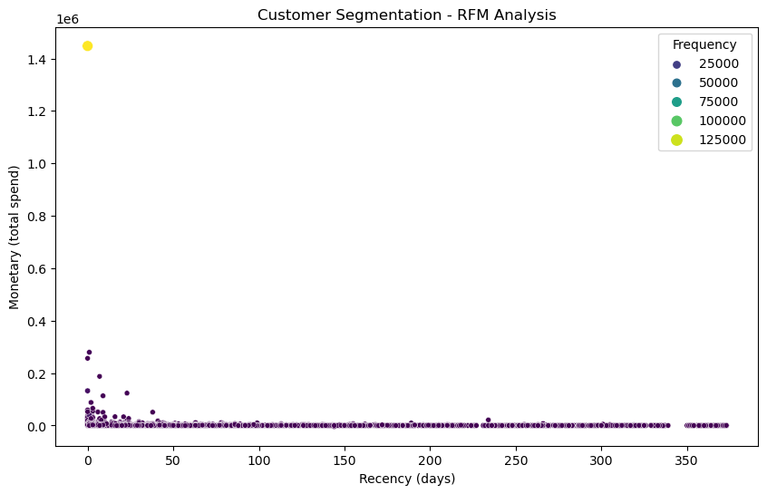

```python
# Customer Segmentation
# Calculate RFM metrics
current_date = data['InvoiceDate'].max()
rfm = data.groupby('CustomerID').agg({
    'InvoiceDate': lambda x: (current_date - x.max()).days,
    'InvoiceNo': 'count',
    'TotalPrice': 'sum'
})
rfm.columns = ['Recency', 'Frequency', 'Monetary']

# Segment customers using quartiles
r_labels = range(4, 0, -1)
f_labels = range(1, 5)
m_labels = range(1, 5)
r_quartiles = pd.qcut(rfm['Recency'], q=4, labels=r_labels)
f_quartiles = pd.qcut(rfm['Frequency'], q=4, labels=f_labels)
m_quartiles = pd.qcut(rfm['Monetary'], q=4, labels=m_labels)
rfm['R'] = r_quartiles
rfm['F'] = f_quartiles
rfm['M'] = m_quartiles
rfm['RFM_Score'] = rfm['R'].astype(str) + rfm['F'].astype(str) + rfm['M'].astype(str)

# Visualize customer segments
plt.figure(figsize=(10, 6))
sns.scatterplot(x='Recency', y='Monetary', hue='Frequency', size='Frequency', data=rfm, palette='viridis')
plt.title('Customer Segmentation - RFM Analysis')
plt.xlabel('Recency (days)')
plt.ylabel('Monetary (total spend)')
plt.show()
```

- SUBJECT TO SCRUTINY 5.3. For the top 5 products (by quantity sold), visualize their monthly sales trend. *

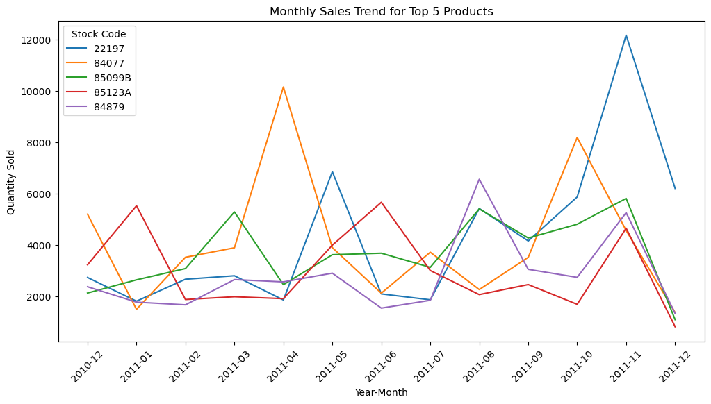

```python
#  Monthly sales trend for top 5 products
top_5_products = data.groupby('StockCode')['Quantity'].sum().nlargest(5).index

data['YearMonth'] = data['InvoiceDate'].dt.to_period('M')
monthly_sales = data[data['StockCode'].isin(top_5_products)].groupby(['YearMonth', 'StockCode'])['Quantity'].sum().unstack()

plt.figure(figsize=(12, 6))
for product in top_5_products:
    plt.plot(monthly_sales.index.astype(str), monthly_sales[product], label=product)

plt.title('Monthly Sales Trend for Top 5 Products')
plt.xlabel('Year-Month')
plt.ylabel('Quantity Sold')
plt.legend(title='Stock Code')
plt.xticks(rotation=45)
plt.show()
```

# Advanced Machine Learning Analysis with Retail Dataset

## 6. Feature Engineering:

6.1 Extract 'Year', 'Month', 'Day', and 'Hour' from the InvoiceDate and create separate columns for each.

```python
# Creating a function to
def df_split_dates(df,colname):
    df["saleyear"] = df[colname].dt.year
    df["salemonth"] = df[colname].dt.month
    df["saleday"] = df[colname].dt.day
    df["saledayofweek"] = df[colname].dt.dayofweek
    df["saledayofyear"] = df[colname].dt.dayofyear
    df["Hour"] = df[colname].dt.hour
    df[colname] = df[colname].astype(np.int64)
```

```python
#data = data.copy()
#data['InvoiceDate'] = pd.to_datetime(data['InvoiceDate'])
```

```python
df_split_dates(data,'InvoiceDate')
data.head(2)
```

|  | InvoiceNo | StockCode | Description | Quantity | InvoiceDate | UnitPrice | CustomerID | Country | TotalPrice | YearMonth | saleyear | salemonth | saleday | saledayofweek | saledayofyear | Hour |
| --- | --- | --- | --- | --- | --- | --- | --- | --- | --- | --- | --- | --- | --- | --- | --- | --- |
| 0 | 536365 | 85123A | WHITE HANGING HEART T-LIGHT HOLDER | 6 | 1291191960000000000 | 2.55 | 17850.0 | United Kingdom | 15.30 | 2010-12 | 2010 | 12 | 1 | 2 | 335 | 8 |
| 1 | 536365 | 71053 | WHITE METAL LANTERN | 6 | 1291191960000000000 | 3.39 | 17850.0 | United Kingdom | 20.34 | 2010-12 | 2010 | 12 | 1 | 2 | 335 | 8 |

```python
data.dtypes
```

```
InvoiceNo           object
StockCode           object
Description         object
Quantity             int64
InvoiceDate          int64
UnitPrice          float64
CustomerID          object
Country             object
TotalPrice         float64
YearMonth        period[M]
saleyear             int32
salemonth            int32
saleday              int32
saledayofweek        int32
saledayofyear        int32
Hour                 int32
dtype: object
```

6.2 Create a new column `'ReturnFlag'` where if `'Quantity'` is less than zero, it's 1, otherwise 0. This will indicate whether an item was returned.

```python
data['ReturnFlag'] = (data['Quantity'] < 0).astype(int)
print(data['ReturnFlag'].value_counts())
data['ReturnFlag'].sample(3)
```

```
ReturnFlag
0    531285
1     10624
Name: count, dtype: int64
```

```
412724    0
389013    0
74955     0
Name: ReturnFlag, dtype: int64
```

## 7. Customer Segmentation using Clustering:

7.1. Create a matrix RFM (Recency, Frequency, Monetary) for each customer:

- Recency: Number of days since the last purchase
- Frequency: Number of purchases
- Monetary: Total money spent

```python
# Calculate Recency, Frequency and Monetary for each customer
# Not Sure why when I use "data" dataframe for this, it gives error
# I know it has something to do with the InvoiceDate
# InvoiceDate datatype is showing as Int, even though its datatype has been changed at the very beginning of the notebook
# However when I use the "new_data" dataframe, it runs
current_date = new_data['InvoiceDate'].max()

rfm = new_data.groupby('CustomerID').agg({
    'InvoiceDate': lambda x: (current_date - x.max()).days,  # Recency
    'InvoiceNo': 'count',                                   # Frequency
    'TotalPrice': 'sum'                                      # Monetary
}).rename(columns={
    'InvoiceDate': 'Recency',
    'InvoiceNo': 'Frequency',
    'TotalPrice': 'Monetary'
})

rfm
```

| CustomerID | Recency | Frequency | Monetary |
| --- | --- | --- | --- |
| 12346.0 | 325 | 1 | 77183.60 |
| 12347.0 | 1 | 182 | 4310.00 |
| 12348.0 | 74 | 31 | 1797.24 |
| 12349.0 | 18 | 73 | 1757.55 |
| 12350.0 | 309 | 17 | 334.40 |
| ... | ... | ... | ... |
| 18281.0 | 180 | 7 | 80.82 |
| 18282.0 | 7 | 12 | 178.05 |
| 18283.0 | 3 | 756 | 2094.88 |
| 18287.0 | 42 | 70 | 1837.28 |
| Guest | 0 | 133359 | 1755276.64 |

4340 rows × 3 columns

7.2. Normalize the RFM matrix with StandardScaler:

```python
scaler = StandardScaler()
rfm_normalized = scaler.fit_transform(rfm)
rfm_normalized
```

```
array([[ 2.33511291e+00, -5.96466166e-02,  2.66058883e+00],
       [-9.05005392e-01,  2.92715457e-02,  6.59483437e-02],
       [-1.74978739e-01, -4.49087997e-02, -2.35176471e-02],
       ...,
       [-8.85004662e-01,  3.11255110e-01, -1.29202731e-02],
       [-4.94990422e-01, -2.57496376e-02, -2.20920361e-02],
       [-9.15005757e-01,  6.54538799e+01,  6.24085378e+01]])
```

7.3. Use KMeans clustering to segment customers into different groups. Determine the optimal number of clusters using the Elbow method.

```python
!pip install -U threadpoolctl
```

```python
import warnings
warnings.filterwarnings("ignore")
```

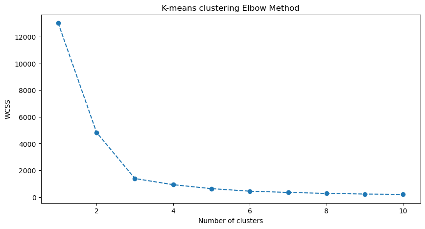

```python
# Determine the optimal number of clusters
wcss = []
for i in range(1, 11):
    kmeans = KMeans(n_clusters=i, init='k-means++', random_state=42)
    kmeans.fit(rfm_normalized)
    wcss.append(kmeans.inertia_)

# Plot the Elbow method
plt.figure(figsize=(10,5))
plt.plot(range(1, 11), wcss, marker='o', linestyle='--')
plt.xlabel('Number of clusters')
plt.ylabel('WCSS')
plt.title('K-means clustering Elbow Method')
plt.show()

# Based on the elbow point, choose optimal clusters and run KMeans
optimal_clusters = 3  # this can change based on your elbow plot
kmeans = KMeans(n_clusters=optimal_clusters, init='k-means++', random_state=42)
clusters = kmeans.fit_predict(rfm_normalized)

rfm['Cluster'] = clusters
```

*Observation: The x-axis represents the number of clusters (K). The y-axis represents the Sum of Squared Errors (SSE) or inertia. Given the shape of the curve, we could consider using 3 or 4 clusters as the optimal number

## 8. Predictive Analytics:

8.1. Can you predict if a customer will return an item? Use the 'ReturnFlag' as the target variable and build a classification model.

- Split data into training and test sets.
- Use features like 'UnitPrice', 'Quantity', etc.
- Evaluate model accuracy, precision, recall, and F1-score.

```python
# Preparing the data for Modelling
numeric_columns = data.select_dtypes(include=['number']).columns
data['InvoiceDate'] = pd.to_datetime(data['InvoiceDate'])
data_numeric = data[numeric_columns]
no_nulls_data= data_numeric.dropna()
no_nulls_data.head(3)
```

|  | Quantity | InvoiceDate | UnitPrice | TotalPrice | saleyear | salemonth | saleday | saledayofweek | saledayofyear | Hour | ReturnFlag |
| --- | --- | --- | --- | --- | --- | --- | --- | --- | --- | --- | --- |
| 0 | 6 | 2010-12-01 08:26:00 | 2.55 | 15.30 | 2010 | 12 | 1 | 2 | 335 | 8 | 0 |
| 1 | 6 | 2010-12-01 08:26:00 | 3.39 | 20.34 | 2010 | 12 | 1 | 2 | 335 | 8 | 0 |
| 2 | 8 | 2010-12-01 08:26:00 | 2.75 | 22.00 | 2010 | 12 | 1 | 2 | 335 | 8 | 0 |

```python
# defining the independent variables X and dependent variable Y
X = no_nulls_data.drop(['InvoiceDate', 'ReturnFlag'], axis=1)
y = no_nulls_data['ReturnFlag']
```

```python
# splitting the dataset
X_train ,X_val, y_train, y_val = train_test_split(X,y, test_size = 0.3)
```

```python
rf = RandomForestRegressor(n_estimators = 100, n_jobs=-1)

rf.fit(X_train,y_train)
```

```
RandomForestRegressor(n_jobs=-1)
```

```python
predictions = rf.predict(X_val)
predictions
```

```
array([0., 0., 0., ..., 0., 0., 0.])
```

```python
rf.score(X_train,y_train)
```

```
1.0
```

```python
rf.score(X_val,y_val)
```

```
1.0
```

```python
print(classification_report(y_val, predictions.astype(int)))
```

```
              precision    recall  f1-score   support

           0       1.00      1.00      1.00    159422
           1       1.00      1.00      1.00      3151

    accuracy                           1.00    162573
   macro avg       1.00      1.00      1.00    162573
weighted avg       1.00      1.00      1.00    162573
```

- SUBJECT TO SCRUTINY

Comments\Obsevations

Class 0 : means not returned Class 1 : means returned

Precision: Out of the instances predicted as class 0 or class 1, what percentage were correct?  
Class 0: 1.00 (100% of predicted class 0 were actually class 0) Class 1: 1.00 (100% of predicted class 1 were actually class 1)

Recall: Out of the actual instances of class 0 or class 1, how many were correctly predicted? Class 0: 1.00 (100% of actual class 0 were predicted correctly) Class 1: 1.00 (100% of actual class 1 were predicted correctly)

F1-Score: Harmonic mean of precision and recall. Class 0: 1.00 (excellent) Class 1: 1.00 (excellent)

Accuracy: Overall accuracy across all classes, which is 1.00 (or 100%).

Macro Average: Averages of precision, recall, and F1-score computed per class, giving equal weight to each class.

Precision, recall, F1-score: 1.00 Weighted Average: Averages of precision, recall, and F1-score, but weighted by the number of instances of each class (i.e., support).

Precision, recall, F1-score: 1.00

8.2. Predict the `'TotalPrice'` for an invoice using regression models.

- Consider relevant features and handle categorical ones appropriately (e.g., with one-hot encoding).
- Split data, train the model, and evaluate its performance using metrics like MAE, RMSE, and R^2.
- This Linear Regression Model BELOW is giving an error, not sure how to fix it.
- SAVING IT as Markdown so that the notebook can run without errors

from sklearn.linear_model import LinearRegression from sklearn.metrics import mean_squared_error, r2_score

# Assuming data has dummy variables for categorical columns

features = data.drop(columns=['TotalPrice']) target = data['TotalPrice'] for col in ['InvoiceDate', 'InvoiceNo','StockCode', 'Description', 'Country', 'CustomerID']: if col in features.columns:  
del features[col]

X_train, X_test, y_train, y_test = train_test_split(features, target, test_size=0.2, random_state=42) reg = LinearRegression() reg.fit(X_train, y_train)

predictions = reg.predict(X_test)

print('RMSE:', mean_squared_error(y_test, predictions, squared=False)) print('R^2:', r2_score(y_test, predictions))

- SUBJECT TO SCRUTINY

RESULT INTERPRETATION

## 9. Association Rule Mining:

- 9.1 Identify frequently bought products together. Use the Apriori algorithm to extract meaningful association rules.
- 9.2 Based on the rules, suggest product bundling strategies to the retail store.

```python
! pip install mlxtend --q
```

```python
from mlxtend.frequent_patterns import apriori, association_rules

# Creating a basket
basket = (data.groupby(['InvoiceNo', 'Description'])['Quantity']
          .sum().unstack().reset_index().fillna(0)
          .set_index('InvoiceNo'))

# Convert the units to 1 hot encoded values
def encode_units(x):
    if x <= 0:
        return 0
    if x >= 1:
        return 1

basket_encoded = basket.applymap(encode_units)

# Build frequent items
frequent_itemsets = apriori(basket_encoded, min_support=0.03, use_colnames=True)

# Association rules
rules = association_rules(frequent_itemsets, metric="lift", min_threshold=1)
rules
```

|  | antecedents | consequents | antecedent support | consequent support | support | confidence | lift | leverage | conviction | zhangs_metric |
| --- | --- | --- | --- | --- | --- | --- | --- | --- | --- | --- |
| 0 | (JUMBO BAG RED RETROSPOT) | (JUMBO BAG PINK POLKADOT) | 0.080772 | 0.047027 | 0.031853 | 0.394359 | 8.385805 | 0.028055 | 1.573496 | 0.958142 |
| 1 | (JUMBO BAG PINK POLKADOT) | (JUMBO BAG RED RETROSPOT) | 0.047027 | 0.080772 | 0.031853 | 0.677340 | 8.385805 | 0.028055 | 2.848904 | 0.924214 |

# Advanced EDA Techniques:

1. Pareto Analysis (80/20 Rule):
- Identify the 20% of the products that generate 80% of the revenue.
- Conversely, identify the 20% of the customers responsible for 80% of the sales.

### Identify the 20% of products generating 80% of the revenue

```python
# Group by StockCode (product ID) and calculate total revenue for each product
product_revenue = new_data.groupby('StockCode')['TotalPrice'].sum().reset_index()
product_revenue = product_revenue.sort_values(by='TotalPrice', ascending=False)
# Calculate cumulative revenue percentage
product_revenue['cumulative_revenue'] = product_revenue['TotalPrice'].cumsum()
total_revenue = product_revenue['TotalPrice'].sum()
product_revenue['cumulative_revenue_percent'] = (product_revenue['cumulative_revenue'] / total_revenue) * 100

# Identify the 20% of products generating 80% of the revenue
cutoff_80_percent = product_revenue[product_revenue['cumulative_revenue_percent'] <= 80]

# Number of products that account for 80% of revenue
top_20_percent_products = len(cutoff_80_percent)

print(f"Number of products that generate 80% of revenue: {top_20_percent_products}")
print(f"Stock code of products that generate 80% of revenue: {cutoff_80_percent['StockCode']}")
```

```
Number of products that generate 80% of revenue: 803
Stock code of products that generate 80% of revenue: 3930       DOT
1313     22423
2470     23843
3424    85123A
2678     47566
         ...
573      21411
1232     22331
691      21625
1774     22906
1652     22777
Name: StockCode, Length: 803, dtype: object
```

### Identify the 20% of customers responsible for 80% of the sales

```python
# Group by CustomerID and calculate total sales for each customer
customer_sales = new_data.groupby('CustomerID')['TotalPrice'].sum().reset_index()
customer_sales = customer_sales.sort_values(by='TotalPrice', ascending=False)
# Calculate cumulative sales percentage
customer_sales['cumulative_sales'] = customer_sales['TotalPrice'].cumsum()
total_sales = customer_sales['TotalPrice'].sum()
customer_sales['cumulative_sales_percent'] = (customer_sales['cumulative_sales'] / total_sales) * 100

# Identify the 20% of customers responsible for 80% of the sales
cutoff_80_percent_customers = customer_sales[customer_sales['cumulative_sales_percent'] <= 80]

# Number of customers that account for 80% of sales
top_20_percent_customers = len(cutoff_80_percent_customers)

print(f"Number of customers that account for 80% of sales: {top_20_percent_customers}")
print(f"Number of customers that account for 80% of sales: {cutoff_80_percent_customers['CustomerID']}")
```

```
Number of customers that account for 80% of sales: 933
Number of customers that account for 80% of sales: 4339      Guest
1690    14646.0
4202    18102.0
3729    17450.0
3009    16446.0
         ...
2591    15864.0
2062    15157.0
146     12528.0
1696    14655.0
1926    14978.0
Name: CustomerID, Length: 933, dtype: object
```

1. Time-Series Anomalies:
- Detect any anomalies or outliers in the sales data over time using rolling averages or other advanced methods.

### Time-Series Setup

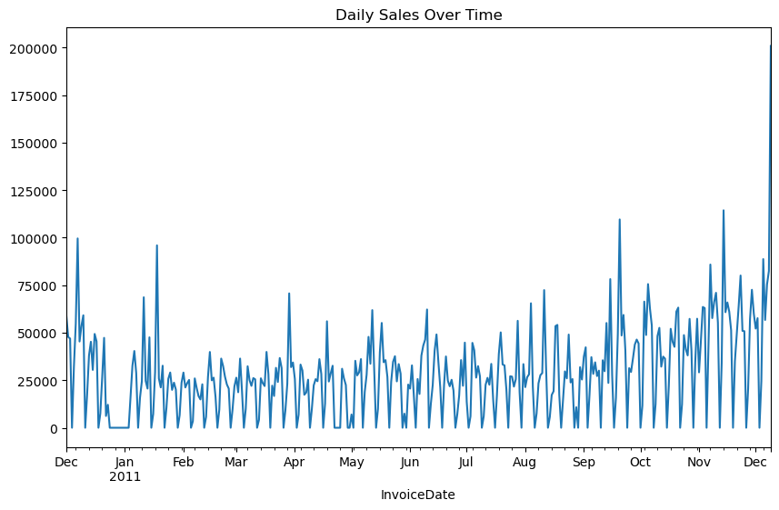

```python
# Resample sales data to daily frequency, summing the sales (TotalPrice)
daily_sales = new_data['TotalPrice'].resample('D').sum()

# Plot the daily sales
daily_sales.plot(title='Daily Sales Over Time', figsize=(10,6))
```

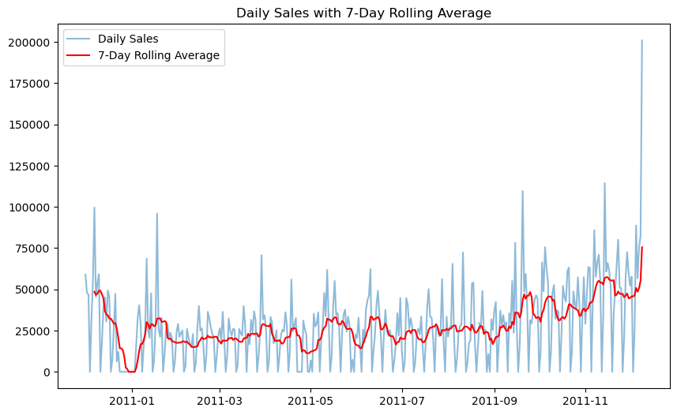

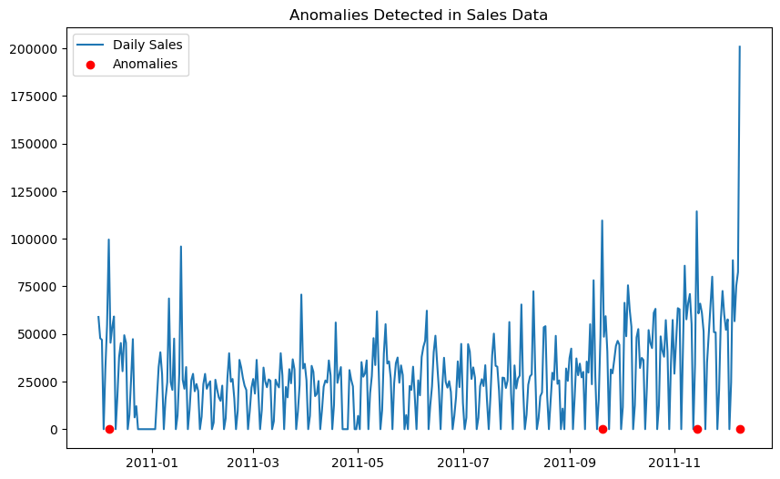

```python
# Calculate a 7-day rolling average
daily_sales_rolling = daily_sales.rolling(window=7).mean()

# Plot rolling average
import matplotlib.pyplot as plt

plt.figure(figsize=(10,6))
plt.plot(daily_sales, label='Daily Sales', alpha=0.5)
plt.plot(daily_sales_rolling, label='7-Day Rolling Average', color='red')
plt.title('Daily Sales with 7-Day Rolling Average')
plt.legend()
plt.show()

# Calculate z-scores to detect anomalies
daily_sales_mean = daily_sales.mean()
daily_sales_std = daily_sales.std()
daily_sales_zscore = (daily_sales - daily_sales_mean) / daily_sales_std

# Define threshold for anomaly (e.g., z-score > 3 or < -3)
threshold = 3
anomalies = daily_sales_zscore[(daily_sales_zscore > threshold) | (daily_sales_zscore < -threshold)]

# Plot anomalies
plt.figure(figsize=(10,6))
plt.plot(daily_sales, label='Daily Sales')
plt.scatter(anomalies.index, anomalies, color='red', label='Anomalies', zorder=5)
plt.title('Anomalies Detected in Sales Data')
plt.legend()
plt.show()
```

## 7 - day rolling Average

Daily Sales (blue line): The blue line shows raw daily sales data, which fluctuate heavily over time. There are several visible spikes and dips throughout the year, suggesting potential anomalies where sales deviate significantly from the normal trend.

7-Day Rolling Average (red line): The red line, representing the 7-day rolling average, smooths out these fluctuations to give a more stable view of the overall sales trend. When analyzing anomalies, the rolling average helps highlight persistent deviations that may indicate genuine sales trends rather than temporary outliers caused by noise.

Late 2011 (September-December): The rolling average shows a gradual rise, especially in the last quarter of the year, indicating a buildup to a major event (likely holiday sales). Anomalies here are likely tied to the extreme spike seen toward the end of the year

## Z - Score Anomalies:

Interpretation: Daily Sales (blue line): The blue line represents the daily sales over time, showing fluctuations in sales values from around 2011 to late 2011. There are noticeable peaks and valleys, with sales spiking significantly at certain points.

Anomalies (red dots): The red dots mark the sales data points that have been identified as anomalies, meaning these points deviate significantly from the average trend. These are based on a z-score threshold (|z| > 3), indicating that the values are more than three standard deviations away from the mean, signaling unusual activity on these dates.

Spike in Sales: Towards the end of the year (November-December 2011), there is a substantial spike in sales, likely corresponding to an important event or seasonal trend (such as holiday sales). This extreme value stands out from the rest of the data and is marked as an anomaly.

# Advanced Modeling Techniques:

1. Market Basket Analysis Enhancements:
- Dig deeper into association rules. For instance, find rules with a high lift and high confidence.
- Analyze antecedents with more than one item, which can give bundled product suggestions.

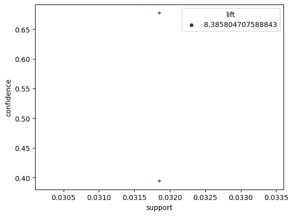

```python
rules = association_rules(frequent_itemsets, metric="lift", min_threshold=0.1)
top_rules = rules[rules['confidence'] > 0.01]
sns.scatterplot(x='support', y='confidence', size='lift', data=top_rules)
```

## Interpretation:

Support (X-axis): Represents the proportion of transactions that contain the itemset in the rule. A support value of around 0.0315 (3.15%) means that the itemset appears in 3.15% of the transactions.

Lift (Bubble Size): The size of the bubbles represents the lift. Lift quantifies how much more likely the consequent is purchased when the antecedent is purchased, compared to random chance.

Interpretation of above graph:

1. Support (X-axis): The support is approximately 0.032, meaning these itemsets appear in around 3.2% of transactions. This is a relatively common itemset or rule within your dataset.
2. Confidence (Y-axis): There are two points, one with a confidence close to 0.65 (65%) and another closer to 0.40 (40%). This suggests that for one rule, 65% of the time when the antecedent is purchased, the consequent is also purchased, indicating a fairly strong association. The other rule has a lower confidence of 40%, showing a weaker, but still notable, association between the antecedent and consequent.
3. Lift (Bubble Size): The single label shows the lift of one rule: 8.39. A lift of 8.39 means that the items in this rule are 8.39 times more likely to be bought together than if they were bought independently. This indicates a strong association between the items in this rule.

Summary: Two rules in this plot. One has high confidence (approx. 65%) and a lift of 8.39, meaning it is both a strong and reliable rule. The other rule has lower confidence (approx. 40%) but may still be useful depending on your business goals. Since both rules have similar support (~3.2%), they occur relatively frequently in your dataset.

## 14. Product Recommendation Systems:

- Develop a system to recommend products to users.
- Consider collaborative filtering techniques, matrix factorization, or deep learning-based approaches like neural collaborative filtering.

```python
# Create a user-product matrix
user_product_matrix = data.pivot_table(index='CustomerID', columns='StockCode', values='Quantity', fill_value=0)
reindexed_user_product_matrix = user_product_matrix.reset_index()
# Compute the cosine similarity matrix
cosine_sim = cosine_similarity(user_product_matrix)

# Get product recommendations for a user based on their purchase history
def get_recommendations(user_id, cosine_sim=cosine_sim):
    idx = reindexed_user_product_matrix[reindexed_user_product_matrix['CustomerID']==user_id].index[0]
    # Get pairwise similarity scores
    sim_scores = list(enumerate(cosine_sim[idx]))

    # Sort users based on similarity scores
    sim_scores = sorted(sim_scores, key=lambda x: x[1], reverse=True)

    # Get products bought by the most similar user
    user_idx = sim_scores[1][0]
    similar_user_products = user_product_matrix.iloc[user_idx]
    recommended_products = similar_user_products[similar_user_products > 0].index.tolist()

    return recommended_products

stockcodelist = get_recommendations(13113.0) # Replace 2154 with an actual CustomerID
print(f"Stockcode list for recommended products are - {stockcodelist}")
```

```
Stockcode list for recommended products are - ['22087', '22668', '47566', '47566B']
```

## 15. Churn Prediction:

- Predict if a customer will stop buying products in the near future.
- Features can include Recency, Frequency, Monetary values, average time between purchases, total categories bought, etc.

```python
# For this example, let's assume if a customer hasn't purchased in the last 6 months, they've churned
new_data['LastPurchase'] = new_data.groupby('CustomerID')['InvoiceDate'].transform('max')
max_date = new_data['InvoiceDate'].max()
new_data['Churn'] = (max_date - new_data['LastPurchase']).dt.days > 180

X = new_data[['TotalPrice', 'Quantity']] # Add more relevant features
y = new_data['Churn']

X_train, X_test, y_train, y_test = train_test_split(X, y, test_size=0.3, random_state=42)

clf = LogisticRegression()
clf.fit(X_train, y_train)

y_pred = clf.predict(X_test)
print(classification_report(y_test, y_pred))
```

```
              precision    recall  f1-score   support

       False       0.96      1.00      0.98    152846
        True       0.00      0.00      0.00      6539

    accuracy                           0.96    159385
   macro avg       0.48      0.50      0.49    159385
weighted avg       0.92      0.96      0.94    159385
```

### Interpretation:

Model Performance Metrics:

1. For Non-Churned Customers (False): Precision: 0.96 The model correctly classifies 96% of the non-churned customers. This is a good performance for this class. Recall: 1.00 The model identifies 100% of non-churned customers correctly, meaning it doesn’t miss any non-churned customers. F1-Score: 0.98 The F1-score, a balanced measure of precision and recall, is very high, confirming strong performance in identifying non-churned customers.
2. For Churned Customers (True): Precision: 0.00 The model is not correctly predicting any churned customers, meaning when the model predicts a customer has churned, it's wrong 100% of the time. Recall: 0.00 The model is failing to identify any of the actual churned customers, meaning none of the customers who have churned are being caught by the model. F1-Score: 0.00 The F1-score is 0 because both precision and recall for the churned class are 0, confirming that the model is unable to handle this class at all.
3. Overall Metrics: Accuracy: 0.96 While the model has high accuracy (96%), this metric is misleading because the dataset is imbalanced. Most customers are non-churned, so the model simply predicting "non-churned" for almost all customers gives high accuracy, but doesn't mean the model is performing well overall. Macro Average (avg): Precision: 0.48, Recall: 0.50, F1-Score: 0.49 The macro average shows that, on average, the model’s performance across both classes is very poor. These low scores reflect the model's failure to predict the churned customers. Weighted Average (avg): Precision: 0.92, Recall: 0.96, F1-Score: 0.94 The weighted average is heavily influenced by the majority class (non-churned customers), which makes it look better than the macro average. This shows that the model is performing well for the majority class but poorly for the minority (churned) class.

Key Insight: The model still cannot detect churned customers at all (0 precision and recall for the churned class). This is a classic case of a model being biased toward the majority class (non-churned customers). The high accuracy is deceptive because the model is not doing well in predicting churned customers, which is the goal.

The model isn’t learning to distinguish between churned and non-churned customers well. The True Churn class (customers who have churned) is likely a minority class, and the model is biased towards predicting the majority class (not churned).

## 16. Hyperparameter Tuning and Model Optimization:

- For any given machine learning model you use, apply techniques like grid search or random search for hyperparameter tuning.
- Use ensemble methods (e.g., stacking, bagging, boosting) to enhance prediction performance.

```python
from sklearn.model_selection import GridSearchCV
from sklearn.linear_model import LogisticRegression
param_grid = {
    'C': [0.1, 1, 10, 100],
    'penalty': ['l2']
}

grid = GridSearchCV(LogisticRegression(), param_grid, verbose=3)
grid.fit(X_train, y_train)

print(grid.best_params_)

grid_predictions = grid.predict(X_test)
print(classification_report(y_test, grid_predictions))
```

[output not shown]

#### Interpretation:

Model Performance After Tuning: After applying the best hyperparameters, the classification report shows the following:

For Non-Churned Customers (False):

Precision: 0.96 When the model predicts a customer has not churned, it is correct 96% of the time. Recall: 1.00 The model correctly identifies 100% of the non-churned customers. F1-score: 0.98 The F1-score, which balances precision and recall, is high, confirming excellent performance for this class.

For Churned Customers (True): Precision: 0.00 When the model predicts a customer has churned, it is never correct, as precision is 0. Recall: 0.00 The model fails to detect any churned customers, so it cannot capture this class at all. F1-score: 0.00 This low F1-score further confirms that the model is not identifying any churned customers.